# SDGB-7844: Homework #5 - Hypothesis Testing & Confidence Intervals

Ryan Waffle

May 9th, 2020

### Two-Sample Hypothesis Test for Proportions

An online men’s clothing retailer has developed a testing framework for video advertising on YouTube in order to test the effectiveness of the ads on influencing individuals to purchase from their website.

Over the course of 30 days, 600,000 consumers were reached on YouTube. Half of the individuals reached with ads on YouTube were served Public Service Announcement ads, while the other half were served ads for the retailer.

Incrementality testing, also referred to as “Uplift Modeling” or “Incremental Sales Lift”, is a test that measures the impact of a single variable on an individual’s behavior. For digital display or video marketing, it is most commonly used to measure the impact of a branded digital ad (Test Group) against a Public Service Announcement (PSA) ad (Control Group). The lift is measured as the percent difference between the two.

Incremental lift indicates the impact of a particular (digital) advertising tactic on sales – the holy grail of advertising. It is possible to calculate but incremental testing is expensive (budget must still be spent on PSA placebo ads) and subject to many pitfalls unless executed carefully. For the purposes of this assignment we will assume that all individuals were not exposed to any other advertising for the retailer during the 30 day testing period.

The goal of our test is to determine whether the conversion rate of the test group is different than the conversion rate of our control group. Conversion rate in this case is defined as
$$\textrm{Conversion Rate} = \Bigg(\frac{ \textrm{Individuals in Group Who Purchased}}{\textrm{Total Individuals in Group}}\Bigg)$$

Our hypothesis will test whether the difference in conversion rate or proportion for the test group and control group is statistically significant when $\alpha$ = 0.01.
$$H_0 : p_{test} - p_{control} = 0$$
$$H_a : p_{test} - p_{control} \neq 0$$

The data we will be using for the following exercises is **test_control.csv**. This data represents a simple random sample of 15,000 individuals served PSA ads and 15,000 individuals served a branded digital video ads. The data also contains an indicator for whether an individual purchased from our retailer after viewing the ad.

1. What variables are available in our data set? List out the column names and describe the data type of each variable.

User_ID - Unique ID given to users who were a part of the test Exposed - Indicates the group that the user was in: PSA Ad or Exposed to Branded Ad Gender - Gender of user Age - Age range of user Income - Income range of user Purchased - Indicates whether or not a user purchased from the retailer

2. How are our test and control samples defined in our data set?

Test users are those users who were served a branded digital ad - identified as Test Group (Exposed). Control users were those users who shown a PSA ad - identified as Control Group (PSA).

3. What proportion of individuals from the test group purchased on the retailer’s website after viewing an ad? What proportion of individuals from the control group purchased on the retailer’s website after viewing an ad?

```r
library(tidyverse)
test_data <- read_csv("test_control.csv")

# Creating new table filtering for only exposed users, aka Test Group (Exposed).
test_data_exposed <- filter(test_data, exposed == "Test Group (Exposed)")
# Finding the total number of users who purchased in the exposed group and dividing by the total number of users in that group.
exp_conv <- round(sum(test_data_exposed$purchased)/length(test_data_exposed$purchased), digits=4)
cat(exp_conv*100, "% of Test Group made a purchase.")
```

```
## 1.21 % of Test Group made a purchase.
```

```r
# Creating new table filtering for only control users, aka Control Group (PSA).
test_data_psa <- filter(test_data, exposed == "Control Group (PSA)")
# Finding the total number of users who purchased in the control group and dividing by the total number of users in that group.
control_conv <- round(sum(test_data_psa$purchased)/length(test_data_psa$purchased), digits=4)
cat(control_conv*100, "% of Control Group made a purchase.")
```

```
## 0.81 % of Control Group made a purchase.
```

4. For each of the variables [$gender$, $age$, $income$] create a bar plot to explore the distribution of demographic information in our samples.

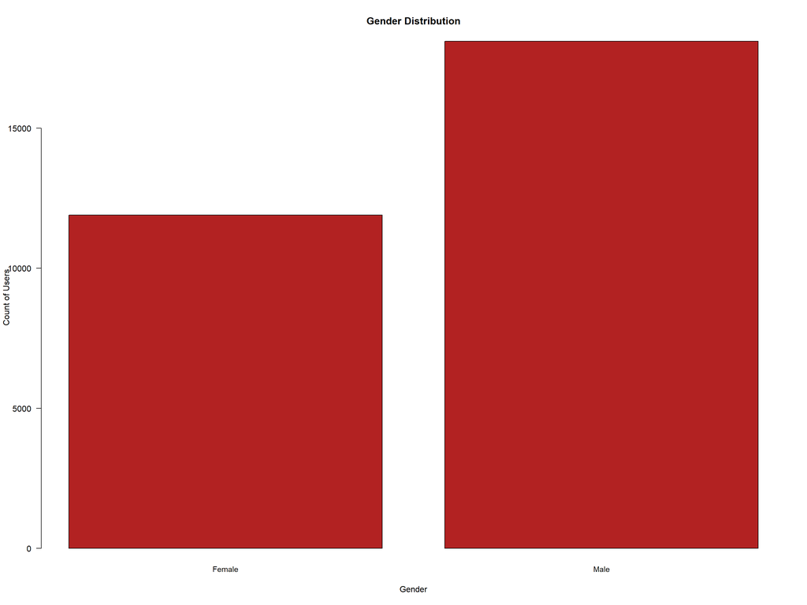

```r
# Creating barplot of Gender Distribution
barplot(sort(table(test_data$gender)), las=TRUE, col="firebrick",
        main="Gender Distribution", cex.names=0.9,
        xlab="Gender", ylab="Count of Users")
```

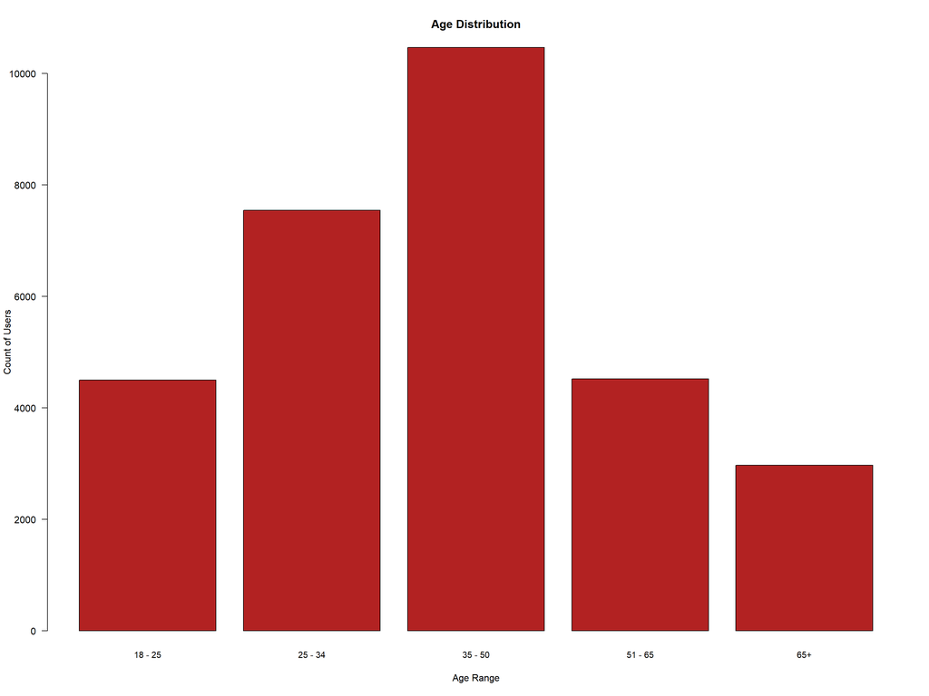

```r
# Creating barplot of Age Distribution
barplot(table(test_data$age), las=TRUE, col="firebrick",
        main="Age Distribution", cex.names=0.9,
        xlab="Age Range", ylab="Count of Users")
```

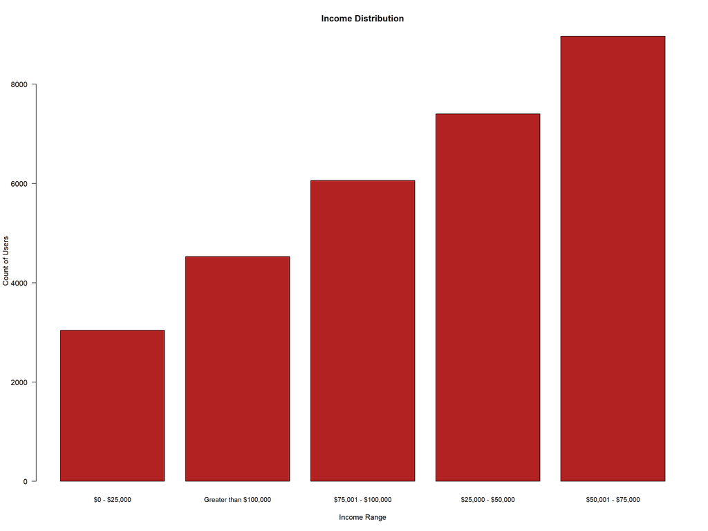

```r
# Creating barplot of Income Distribution
barplot(sort(table(test_data$income)), las=TRUE, col="firebrick",
        main="Income Distribution", cex.names=0.9,
        xlab="Income Range", ylab="Count of Users")
```

5. Create a figure with two bar plots (one for the test group and one for the control group) for $age$. Describe the difference in the distribution between the test and control groups. Compare the percentage of each category between our test and control groups.

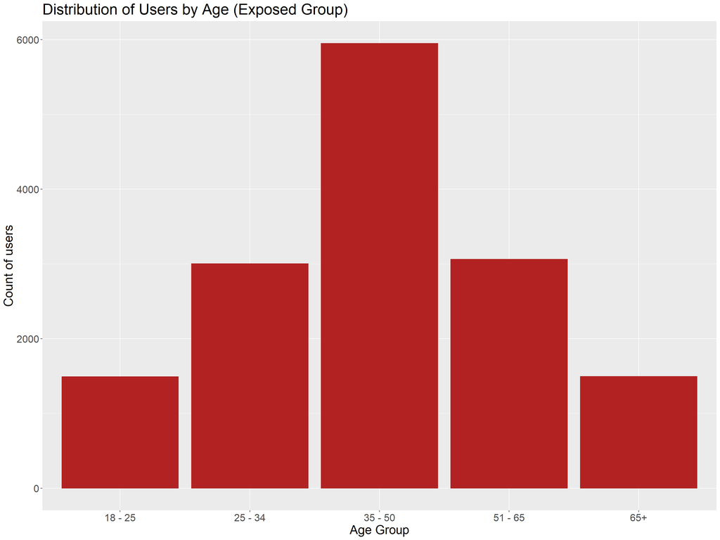

```r
# Creating plot area with one row and two columns for two plots.
par(mfrow=c(1,2))

# Using dplyr to filter the test data to filter for both control and exposed, based on the age of the groups
test_data%>%
  # Test Group Only
  filter(exposed=="Test Group (Exposed)") %>%
  ggplot() +
  geom_bar(mapping = aes(x = age), color = "firebrick", fill = "firebrick") +
  theme(text = element_text(size=20)) +
  labs(title = "Distribution of Users by Age (Exposed Group)", x = "Age Group", y = "Count of users")
```

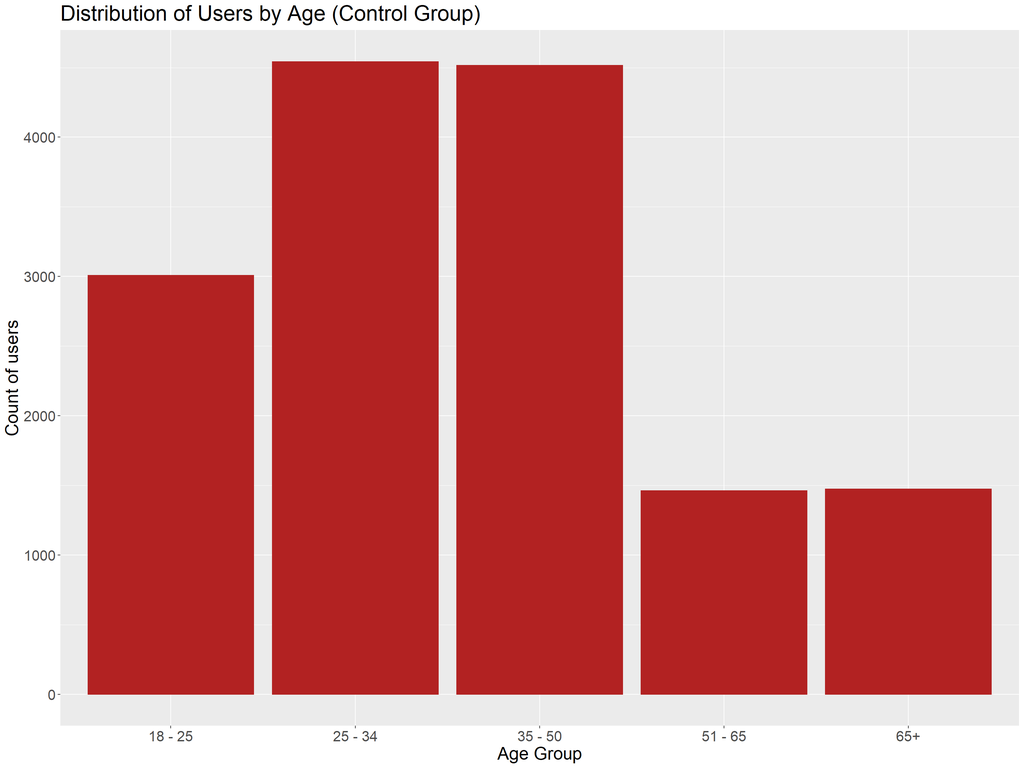

```r
test_data%>%
  # Control Group Only
  filter(exposed=="Control Group (PSA)") %>%
  ggplot() +
  geom_bar(mapping = aes(x = age), color = "firebrick", fill = "firebrick") +
  theme(text = element_text(size=20)) +
  labs(title = "Distribution of Users by Age (Control Group)", x = "Age Group", y = "Count of users")
```

The distribution of the Exposed Group has a more normally distributed curve, with the largest number of users in the middle catgory (35-50). The distribution of the Control Group is more skewed toward the younger age groups. The Exposed group contains more users in the 35-50, 51-65 and 65+ categories, while the Control group has more users in the 18-25 and 25-34 age groups.

6. Create a figure with two bar plots (one for the test group and one for the control group) for $gender$. Describe the difference in the distribution between the test and control groups. Add the percentage of each category to your plots. Why might this variable be important to our analysis?

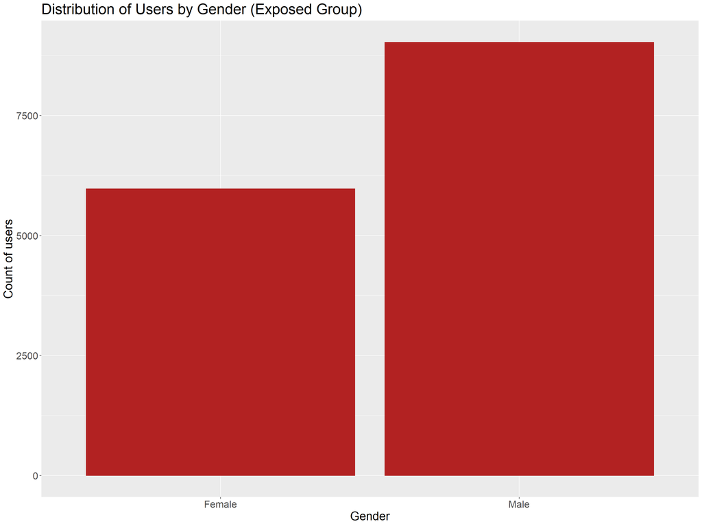

```r
# Creating plot area with one row and two columns for two plots.
par(mfrow=c(1,2))

test_data%>%
  # Test Group Only
  filter(exposed=="Test Group (Exposed)") %>%
  ggplot() +
  geom_bar(mapping = aes(x = gender), color = "firebrick", fill = "firebrick") +
  theme(text = element_text(size=20)) +
  labs(title = "Distribution of Users by Gender (Exposed Group)", x = "Gender", y = "Count of users")
```

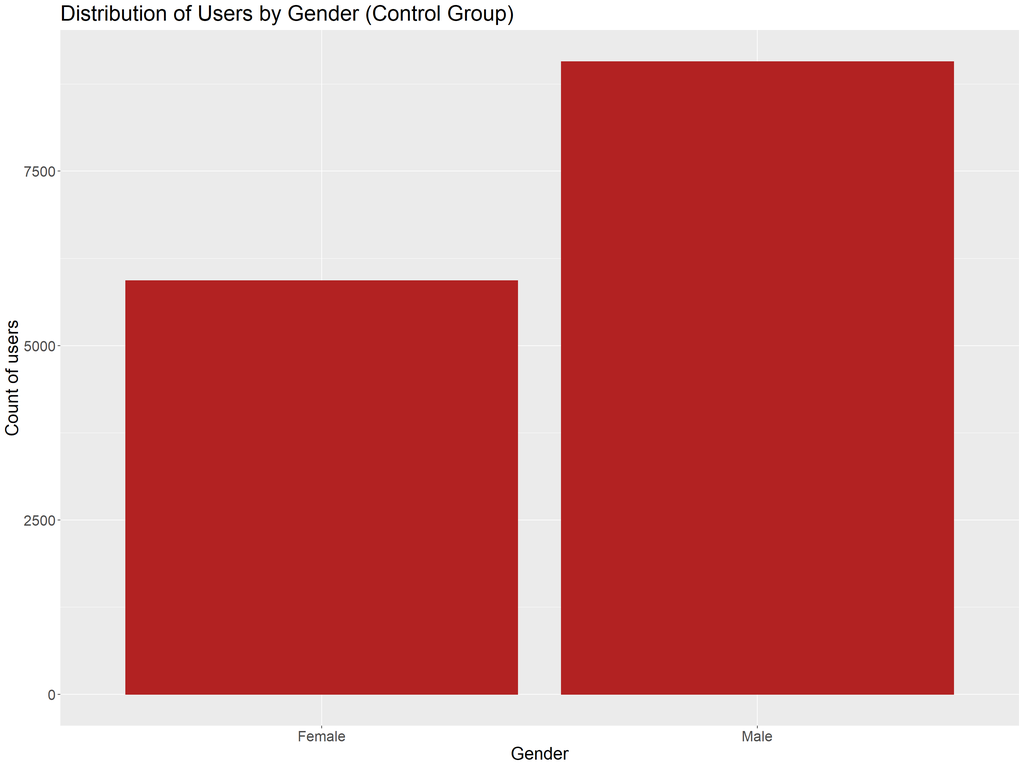

```r
test_data%>%
  # Control Group Only
  filter(exposed=="Control Group (PSA)") %>%
  ggplot() +
  geom_bar(mapping = aes(x = gender), color = "firebrick", fill = "firebrick") +
  theme(text = element_text(size=20)) +
  labs(title = "Distribution of Users by Gender (Control Group)", x = "Gender", y = "Count of users")
```

The gender of both groups appears mostly equal. The Control Group may have slightly more Male users than the Exposed group.

7. Create a figure with two bar plots (one for the test group and one for the control group) for $income$. Describe the difference in the distribution between the test and control groups. Compare the percentage of each category between our test and control groups.

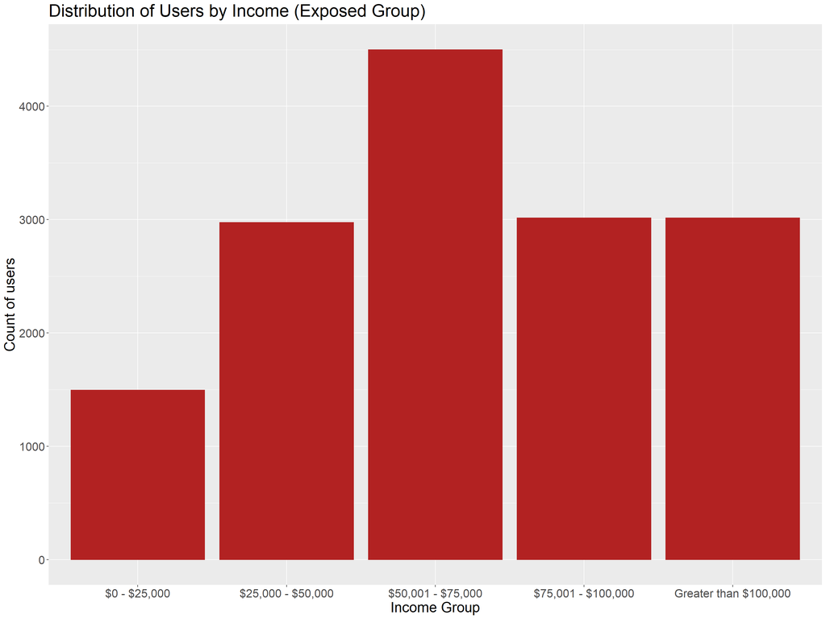

```r
# Creating plot area with one row and two columns for two plots.
par(mfrow=c(1,2))

test_data%>%
  # Test Group Only
  filter(exposed=="Test Group (Exposed)") %>%
  ggplot() +
  geom_bar(mapping = aes(x = income), color = "firebrick", fill = "firebrick") +
  theme(text = element_text(size=20)) +
  labs(title = "Distribution of Users by Income (Exposed Group)", x = "Income Group", y = "Count of users")
```

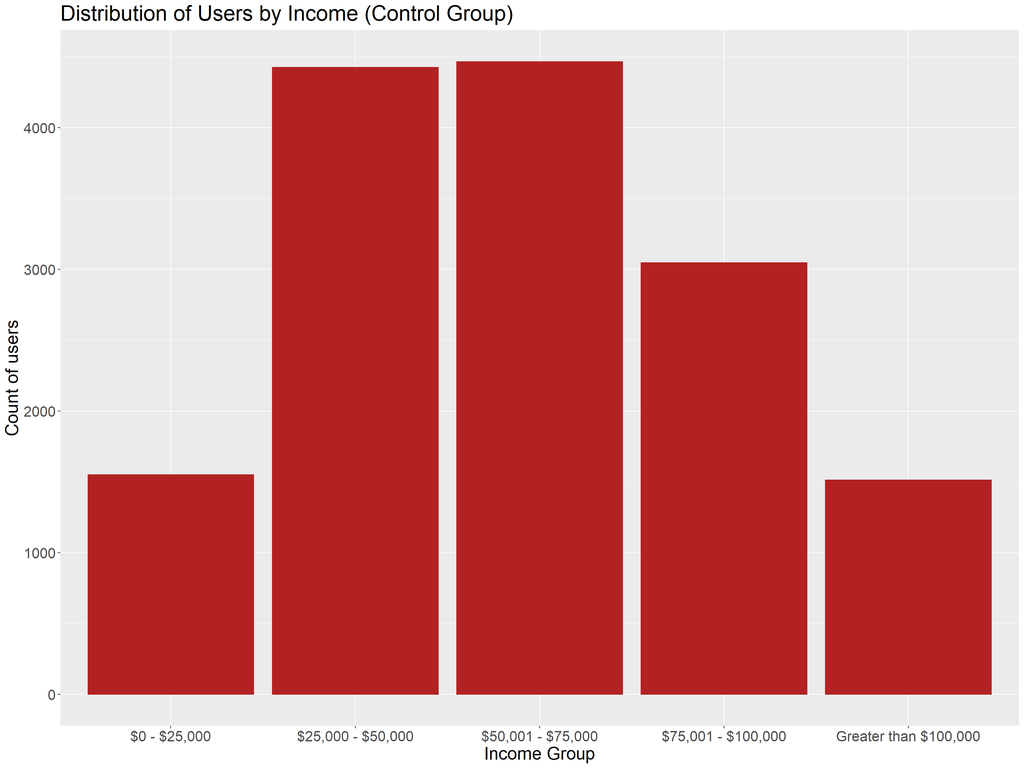

```r
test_data%>%
  # Control Group Only
  filter(exposed=="Control Group (PSA)") %>%
  ggplot() +
  geom_bar(mapping = aes(x = income), color = "firebrick", fill = "firebrick") +
  theme(text = element_text(size=20)) +
  labs(title = "Distribution of Users by Income (Control Group)", x = "Income Group", y = "Count of users")
```

Similar to the age group distributions, the Income Groups are more normally distributed in the Exposed Group, while the Control Group has a skew toward lower incomes. Both groups contain relatively equal numbers of users in the 0-25000, 50001-75000, and 75000-100000 income groups. However the Control group contains more users in the 25000-50000 group and fewer users in the Greater than 100000 group.

8. How might the differences in the distributions of the categorical variables analyzed in #5 - #7 impact our analysis? Is it possible that our two samples may represent different types of shoppers?

Our analysis may be slightly dirtied due to the demographics of the users, especially due to incomes and age groups. For example, users in higher incomes may be more likely to purchase than users in lower income groups, due to their disposable incomes. Older users may also be more likely to purchase due to more flexible or saved incomes than younger users. Since the control and exposed groups can vary in terms of their ages and incomes, with Exposed users being generally older with higher incomes, the exposed group may, without any ads, be more likely to purchase.

#### Hypothesis Test

9. What is the difference in the conversion rate for the test and control groups?

```r
# Taking the differnce between conversion rates which were calculated earlier.
conv_diff <- exp_conv-control_conv
conv_diff
```

```
## [1] 0.004
```

The confidence interval for the difference between two proportions (when n > 30) is defined as
$$p_{test} - p_{control} \pm z_{\alpha/2}\sqrt{\frac{p_{test} \times (1-p_{test})}{n_{test}}+ \frac{p_{control} \times (1-p_{control})}{n_{control}} }$$

10. Using the equation above, write a function to calculate the confidence interval for the difference between two proportions. Your function should include three arguments: p1, p2, n1, n2 and Z. Your function should return the confidence interval for the difference in two proportions at a given confidence level (in our example, Z = 2.575 when $\alpha$ = 0.01) Round your results to the first five decimal places.

```r
# Creating confidence interval function using the provided equation
confidence <- function(p1, p2, n1, n2, z){
  # Finding the lower confidence interval based on the given equation
  lower_confidence_interval <- p1-p2-(z*(sqrt((p1*(1-p1)/n1) + (p2*(1-p2)/n2))))
  # Finding the upper confidence interval based on the given equation
  upper_confidence_interval <- p1-p2+(z*(sqrt((p1*(1-p1)/n1) + (p2*(1-p2)/n2))))
  # Creating vector for both confidence intervals, with 5 decimal places
  confidence_interval <- round(c(lower_confidence_interval, upper_confidence_interval), digits = 5)
  return(confidence_interval)
}
```

11. Calculate the confidence interval for the difference between the conversion rates for our test and control groups when $\alpha$ = 0.01 (Z = 2.575) using your function. Does this confidence interval include zero? What are the implications for the difference between two means when the confidence interval does not include zero?

```r
#Calling our function using the number of exposed and control, and z value of 2.575
confidence(exp_conv, control_conv, 15000, 15000, 2.575)
```

```
## [1] 0.00103 0.00697
```

No, this interval does not include 0. A confidence interval for a two sided hypothesis that does not include zero would imply that there is indeed a significant difference between two proportions or conversion rates. This confident interval suggests that given the 99% confidence level, the difference between the means for each proportion should not be equal to zero, which will allow the null hypothesis to be rejected.

12. Similar to the `t.test()` function in R, the `prop.test()` function can be used for testing the null hypothesis that the proportions (probabilities of success) in several groups are the same, or that they equal certain given values. A chi-square test for equality of two proportions is exactly the same test as a z-test (chi-squared distribution with one degree of freedom is just that of a normal deviate, squared). What are the arguments for the function `prop.test()`?

```r
?prop.test
```

The arguments of prop.test() are: [x] - X is the vector of how many successes from our data. Can also be a table. [n] - N is the vector with how many trials are in our data. [p] - The probabilities of success. Defaults to null. [alternative] - Either two sided, greater or less. Tests to see if the proportions are equal or if one proportion equals a value. [conf.level] - Specifies the confidence level of the confidence interval. [correct] - Whether or not to apply the Yates continuity correction.

13. Noting that the arguments `x` and `n` require vectors of values, use the `prop.test()` function to test our hypothesis that there is a statistically significant difference between the conversion rates of our test and control groups.

```r
# Calling the prop test function with the number of users who purchased in both groups.
# Also using the number of users in each group (15000), the two sided test, with a confidence interval and the Yates correction applied.
prop.test(c(181, 121), c(15000, 15000), alternative = 'two.sided', conf.level = 0.99, correct = FALSE)
```

```
##
##  2-sample test for equality of proportions without continuity
##  correction
##
## data:  c(181, 121) out of c(15000, 15000)
## X-squared = 12.042, df = 1, p-value = 0.0005202
## alternative hypothesis: two.sided
## 99 percent confidence interval:
##  0.001031445 0.006968555
## sample estimates:
##      prop 1      prop 2
## 0.012066667 0.008066667
```

14. Interpet each output of `prop.test`. Explain your p-value in the context of our hypothesis. Is the difference in the conversion rates for the test and control groups statistically significant?

Our null hypothesis for this data is there theres is no difference between the conversion rates of both the control and exposed groups. Given that we are using a two-sided test, we are looking to see that there is any difference between the two, whether one is higher or lower than the other. Prop.test provides a p value of 0.0005, which suggests that there is a very small chance that there is no difference between the two proportions, and the null hypothesis can be rejected.

15. Use the function `pchisq(x, df=1)` to try to understand the **X-squared** score value in the output of `prop.test()`. What do the “p” functions for distributions calculate in R? Subtract the value calculated using `pchisq` from 1. What does this value represent?

```r
pchisq(12.042, df=1)
```

```
## [1] 0.9994798
```

```r
?pchisq
1 - pchisq(12.042, df=1)
```

```
## [1] 0.0005201513
```

The p functions for distributions calculate the probability of a random variable being less than or equal to one possible outcome in the sample space, i.e. the cumulative distribution function. The value calculated from pchisq is the probability that our two proportions are different from one another. Subtracting this value from one provides us a p value, which suggests whether or not the null hypothesis that there is no difference between the two proportions can be rejected.

#### Conclusion

16. In a few sentences, describe your interpretation of the results we found in this assignment. How might the demographic data we observed for our test and control groups impact the difference in the two conversion rates? Do you still believe that the results of our hypothesis test is valid? Justify your answer.

We found in this assignment that ads may have been effective in driving more exposed users to transact compared to control users. There was a statistically significant difference between the two groups based on our testing the proportions of both groups. However, our results may have been influenced by the demographics between the two groups. Since the exposed group contained older users with higher incomes, they may have been more likely to purchase, without the influence of ads. However, this may work in the opposite direction depending on the targets of the campaign. If the product was actually designed for younger audiences, the older skew of the exposed group may have worked against it, and may have led to fewer purchases than what would have been possible with a more even age distribution. I believe that this test is still valid for that very reason - based on statistics alone, the exposed group “performed” better. Without additional outside information that may lend more insight into the demographics and the ads themselves, it would be difficult to say that the results are invalid.